# Homework 3: Calculus Solutions

## Problem 1: Limits of Sequences

Does the following sequence have a limit (as $n\to\infty$)? If so, find it.

1. $\dfrac{3-n}{2}$
2. $\dfrac{4\sqrt{n}}{n^3}$
3. $\dfrac{n-1}{n^2-1}$
4. $1^n$
5. $0.4^n$
6. $(-4)^n$
7. Choose any number as the first term; divide it by $1.5$ to get the next term; then repeat the same step again and again.
8. $a_1=1$; $a_2 =$ the first digit of $a_1/7$ after the decimal point; $a_3 =$ the first digit of $a_2/7$ after the decimal point; $\dots$

### Solutions

1. $\dfrac{3-n}{2} = -\dfrac{n}{2}+\dfrac{3}{2} \to -\infty$. No finite limit; the sequence diverges to $-\infty$.
2. $\dfrac{4\sqrt{n}}{n^3}=4n^{-5/2}\to 0$.
3. $\dfrac{n-1}{n^2-1}=\dfrac{n-1}{(n-1)(n+1)}=\dfrac{1}{n+1}$ (for $n\neq 1$), hence $\to 0$.
4. $1^n=1$ for all $n$; limit $=1$.
5. $|0.4|<1\Rightarrow 0.4^n\to 0$.
6. $(-4)^n$ has magnitude $4^n\to\infty$ and alternates in sign; no limit (diverges).
7. If $a_{n+1}=\dfrac{a_n}{1.5}=\dfrac{2}{3}a_n$, then $a_n=a_1\left(\dfrac{2}{3}\right)^{n-1}\to 0$ for any $a_1$. Limit $=0$.
8. $a_1=1$. Since $1/7=0.\overline{142857}$, the first digit after the decimal is $1$; thus $a_2=1$. Repeating gives $a_3=1$, etc. So $a_n=1$ for all $n\ge 1$; limit $=1$.

## Problem 2: Continuity

The following functions consist of two “parts” which are glued together at $x=2$. Is there a value of $c$ such that the functions are continuous at $x=2$?

1. $f(x)=\begin{cases} 3x-5,& \text{if } x< 2 \\ x^2+c,& \text{if } x\ge2 \end{cases}$
2. $f(x)=\begin{cases} x^3+1,& \text{if } x<2 \\ cx^2,& \text{if } x\ge2 \end{cases}$
3. $f(x)=\begin{cases} -7,& \text{if } x<2 \\ c,& \text{if } x=2 \\ 4+3\sin(\pi x),& \text{if } x>2 \end{cases}$
4. $f(x)=\begin{cases} \dfrac{x^2-x-2}{x-2},& \text{if } x\neq 2 \\ c,& \text{if } x=2 \end{cases}$

### Solutions

1. For continuity at $x=2$: $\lim_{x\to 2^-} f(x) = \lim_{x\to 2^+} f(x) = f(2)$
   - $\lim_{x\to 2^-} (3x-5) = 3(2)-5 = 1$
   - $f(2) = 2^2+c = 4+c$
   - For continuity: $1 = 4+c \Rightarrow c = -3$
2. For continuity at $x=2$:
   - $\lim_{x\to 2^-} (x^3+1) = 8+1 = 9$
   - $f(2) = c(2)^2 = 4c$
   - For continuity: $9 = 4c \Rightarrow c = \dfrac{9}{4}$
3. For continuity at $x=2$:
   - $\lim_{x\to 2^-} (-7) = -7$
   - $\lim_{x\to 2^+} (4+3\sin(\pi x)) = 4+3\sin(2\pi) = 4+3(0) = 4$
   - Since left and right limits differ ($-7 \neq 4$), no value of $c$ makes the function continuous at $x=2$.
4. First simplify $\dfrac{x^2-x-2}{x-2} = \dfrac{(x-2)(x+1)}{x-2} = x+1$ for $x\neq 2$
   - $\lim_{x\to 2} (x+1) = 3$
   - For continuity: $c = 3$

## Problem 3: Investment Growth (Limits)

Zeus, Prometheus and Aramazd invest 1000 gold coins each in different banks with growth functions: - OlympusBank: $f(x)=100x+x^3$ - TaurusBank: $f(x)=0.18x^3\sqrt{x} = 0.18x^{7/2}$ - AraratBank: $f(x)=30x^2$

Who will be richest after infinitely long time?

### Solution

Compare the growth rates as $x \to \infty$: - OlympusBank: $100x+x^3 \sim x^3$ (cubic growth) - TaurusBank: $0.18x^{7/2}$ (power $7/2 = 3.5$) - AraratBank: $30x^2$ (quadratic growth)

Since $7/2 > 3 > 2$, TaurusBank grows fastest. **Prometheus** will be the richest.

## Problem 4: Derivatives

Find the derivatives of the following functions:

1. $f(x)=10000$
2. $f(x)=2x^2-7x+1$
3. $f(x)=2\sin x \cdot e^x$
4. $f(x)=e^{x^2}$
5. $f(x)=x^2\ln x$
6. $f(x)=\dfrac{x^2}{x^3}$

**Neural Network Activation Functions**

The next two functions (ReLU and Sigmoid) are **activation functions** - fundamental building blocks of neural networks and machine learning models. Understanding their derivatives is crucial for training neural networks through backpropagation. We’ll cover these topics in detail in our machine learning chapters.

7. ReLU: $f(x) = \begin{cases} x, & \text{if } x>0\\ 0, & \text{if } x\le 0 \end{cases}$

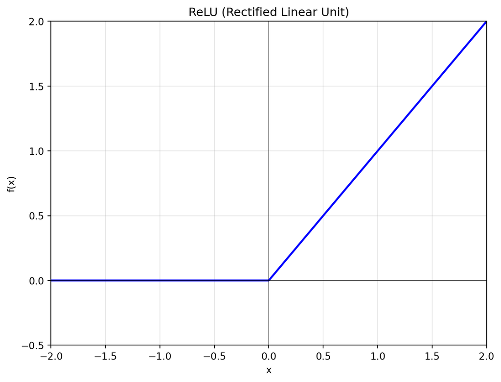

Figure 1: ReLU (Rectified Linear Unit) Function

8. Sigmoid: $f(x) = \dfrac{1}{1+e^{-x}}$

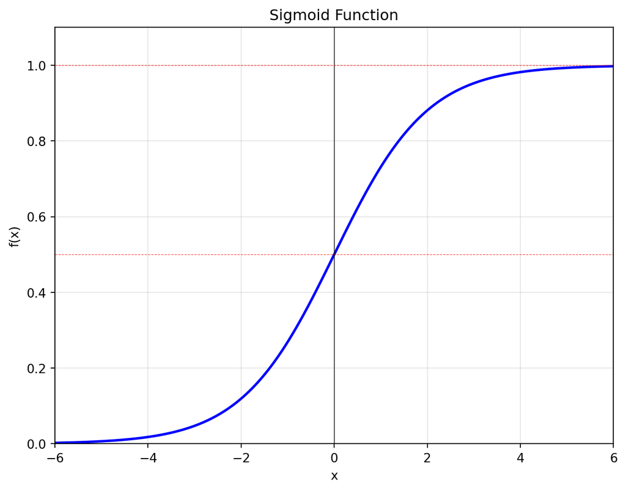

Figure 2: Sigmoid Function

### Solutions

1. $f'(x) = 0$ (derivative of constant)
2. $f'(x) = 4x - 7$ (power rule)
3. $f'(x) = 2(\sin x \cdot e^x)' = 2(e^x \sin x + e^x \cos x) = 2e^x(\sin x + \cos x)$ (product rule)
4. $f'(x) = e^{x^2} \cdot 2x = 2xe^{x^2}$ (chain rule)
5. $f'(x) = 2x \ln x + x^2 \cdot \dfrac{1}{x} = 2x \ln x + x$ (product rule)
6. $f(x) = \dfrac{x^2}{x^3} = x^{-1}$, so $f'(x) = -x^{-2} = -\dfrac{1}{x^2}$
7. **ReLU (Rectified Linear Unit)**: $f'(x) = \begin{cases} 1, & \text{if } x>0\\ 0, & \text{if } x<0\\ \text{undefined}, & \text{if } x=0 \end{cases}$

   Note: At $x=0$, the function has a “corner” where left and right derivatives differ:
   - Right derivative: $\lim_{h \to 0^+} \frac{h-0}{h} = 1$
   - Left derivative: $\lim_{h \to 0^-} \frac{0-0}{h} = 0$

   Since $1 \neq 0$, ReLU is not differentiable at $x=0$.
8. **Sigmoid**: $f'(x) = \dfrac{d}{dx}\left(\dfrac{1}{1+e^{-x}}\right)$

   Using the chain rule: $f'(x) = \dfrac{0 \cdot (1+e^{-x}) - 1 \cdot (-e^{-x})}{(1+e^{-x})^2} = \dfrac{e^{-x}}{(1+e^{-x})^2}$

   This can be rewritten elegantly as: $f'(x) = \dfrac{1}{1+e^{-x}} \cdot \dfrac{e^{-x}}{1+e^{-x}} = f(x) \cdot (1-f(x))$

   **ML Note**: This self-referential property ($f'(x) = f(x)(1-f(x))$) makes sigmoid derivatives very efficient to compute in neural networks!

## Problem 5: Differentiability of Absolute Value (Additional)

Prove that the function $f(x)=|x|$ is not differentiable at $x=0$.

### Solution

We use the definition of derivative. For $f(x) = |x|$ to be differentiable at $x=0$, the limit
$$f'(0) = \lim_{h \to 0} \frac{f(0+h) - f(0)}{h} = \lim_{h \to 0} \frac{|h| - |0|}{h} = \lim_{h \to 0} \frac{|h|}{h}$$
must exist.

However, we need to check left and right limits:

**Right limit** ($h \to 0^+$): $\lim_{h \to 0^+} \frac{|h|}{h} = \lim_{h \to 0^+} \frac{h}{h} = 1$

**Left limit** ($h \to 0^-$): $\lim_{h \to 0^-} \frac{|h|}{h} = \lim_{h \to 0^-} \frac{-h}{h} = -1$

Since the left and right limits are different ($1 \neq -1$), the limit does not exist. Therefore, $f(x) = |x|$ is not differentiable at $x=0$.

## Problem 6: Matrix Determinant Derivative (Additional)

Consider a matrix $A = \begin{bmatrix} a & b \\ c & d \end{bmatrix}$ and define $f(x) = \det(A + x \cdot I)$ where $I$ is the identity matrix.

1. What is $f(0)$?
2. Using the definition of derivative, find $f'(0)$.
3. Do you recognize the result?

### Solutions

[📹 Video Solution in Armenian](https://youtu.be/BnhCUCzmWeM)

1. $f(0) = \det(A + 0 \cdot I) = \det(A) = ad - bc$
2. First, let’s compute $f(x)$:
   $$A + x \cdot I = \begin{bmatrix} a+x & b \\ c & d+x \end{bmatrix}$$

   So $f(x) = \det\begin{bmatrix} a+x & b \\ c & d+x \end{bmatrix} = (a+x)(d+x) - bc = ad + x(a+d) + x^2 - bc$

   Therefore: $f(x) = ad - bc + x(a+d) + x^2$

   Using the definition of derivative:
   $$f'(0) = \lim_{x \to 0} \frac{f(x) - f(0)}{x} = \lim_{x \to 0} \frac{ad - bc + x(a+d) + x^2 - (ad - bc)}{x}$$
   $$= \lim_{x \to 0} \frac{x(a+d) + x^2}{x} = \lim_{x \to 0} (a+d+x) = a+d$$
3. The result $f'(0) = a + d$ is the **trace** of matrix $A$! This shows that the derivative of the determinant function at the identity gives the trace.

## Problem 7: Local Maxima and Minima

Find local maxima and minima:

1. $f(x)=5x-x^2$
2. $f(x)=3x+1$
3. $f(x)=\dfrac{x^3}{e^x}$

## Problem 8: Box Optimization (Additional)

You have 24 square meters of cardboard and want to make a box where the left and right sides are squares. What is the maximum volume your box can have?

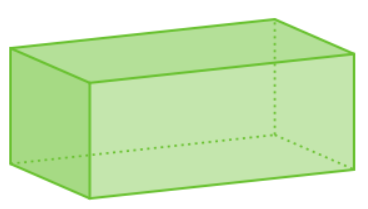

Box with square ends

*Hint: Take one of the non-square sides and denote its length and width by $x$ and $y$. Can you express $y$ by $x$? Can you also express the volume by $x$?*

### Solution

[📹 Video Solution in Armenian](https://youtu.be/f2Bp77tiESg)

Let the square sides have side length $x$, and the rectangular sides have dimensions $x \times y$.

**Surface area constraint:** - Two square sides: $2x^2$  
- Four rectangular sides: $4xy$ - Total: $2x^2 + 4xy = 24$

From the constraint: $y = \dfrac{24 - 2x^2}{4x} = \dfrac{12 - x^2}{2x}$

**Volume function:** $V(x) = x^2 \cdot y = x^2 \cdot \dfrac{12 - x^2}{2x} = \dfrac{x(12 - x^2)}{2} = \dfrac{12x - x^3}{2}$

**Finding the maximum:** $V'(x) = \dfrac{12 - 3x^2}{2} = 0$

$12 - 3x^2 = 0 \Rightarrow x^2 = 4 \Rightarrow x = 2$

$V''(x) = \dfrac{-6x}{2} = -3x < 0$ for $x > 0$, confirming a maximum.

**Maximum volume:** At $x = 2$, we get $y = \frac{12 - 4}{2 \cdot 2} = \frac{8}{4} = 2$

Therefore: $V_{\max} = x^2 \cdot y = 4 \cdot 2 = 8$ cubic meters.

## Problem 9: Integration

Calculate $\displaystyle \int f(x)\, dx$:

1. $f(x)=3x^2$
2. $f(x)=x+6\cos x$
3. $f(x)=\dfrac{3}{x}-1$
4. $f(x)=\dfrac{4x}{1-2x^2}$
5. $f(x)=\tan x$

### Solutions

1. $\int 3x^2 dx = x^3 + C$
2. $\int (x+6\cos x) dx = \dfrac{x^2}{2} + 6\sin x + C$
3. $\int \left(\dfrac{3}{x}-1\right) dx = 3\ln|x| - x + C$
4. Let $u = 1-2x^2$, then $du = -4x dx$ $\int \dfrac{4x}{1-2x^2} dx = -\int \dfrac{du}{u} = -\ln|u| + C = -\ln|1-2x^2| + C$
5. $\int \tan x dx = \int \dfrac{\sin x}{\cos x} dx = -\ln|\cos x| + C$

## Problem 10: Distance and Average Speed

A spaceship has speed $f(x) = x^5+x^2$ thousand km/h at time $x$ hours.

1. How much distance does it pass in the first 3 hours?
2. What was its average speed?

### Solutions

[📹 Video Solution in Armenian](https://youtu.be/avDg6SmyMoY)

1. Distance = $\int_0^3 (x^5+x^2) dx = \left[\dfrac{x^6}{6} + \dfrac{x^3}{3}\right]_0^3 = \dfrac{729}{6} + \dfrac{27}{3} = 121.5 + 9 = 130.5$ thousand km
2. Average speed = $\dfrac{\text{total distance}}{\text{time}} = \dfrac{130.5}{3} = 43.5$ thousand km/h

## Problem 11: Equal Areas (Additional)

The graph of the function $f(x) = -x \cdot \ln(x^2)$ on the interval $0 < x < 1$ is plotted below. It is known that the area of the green and blue regions are the same. What is the height of the blue rectangle?

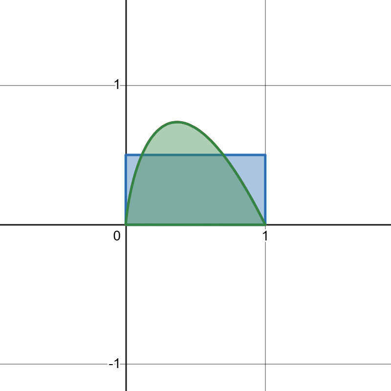

Equal areas problem

### Solution

[📹 Video Solution in Armenian](https://youtu.be/EWhCu2C-d0M)

This problem requires finding where the areas under the curve are equal. Let’s call the height of the rectangle $h$ and assume it extends from $x = a$ to $x = b$.

For equal areas:
$$\int_a^c f(x) dx = h \cdot (b - a)$$

where $c$ is the point where the curve intersects the rectangle.

First, let’s simplify $f(x) = -x \ln(x^2) = -x \cdot 2\ln(x) = -2x\ln(x)$.

The critical point occurs when $f'(x) = 0$: $f'(x) = -2\ln(x) - 2x \cdot \frac{1}{x} = -2\ln(x) - 2 = -2(\ln(x) + 1) = 0$

This gives $\ln(x) = -1$, so $x = e^{-1} = \frac{1}{e}$.

At this point: $f\left(\frac{1}{e}\right) = -2 \cdot \frac{1}{e} \cdot \ln\left(\frac{1}{e}\right) = -2 \cdot \frac{1}{e} \cdot (-1) = \frac{2}{e}$